# Stable Isotopes - Seasonality (short version)

Nicole LaRoche

2/6/2020

# Introduction

I am working on sea otter whisker analysis over time from the root to the tip of the whisker. This includes 29 sea otters as a population between Klawock and Naukati on Prince of Wales Island. Sea otter whiskers were collected from June 26- August 6, 2019. We are looking at seasonality (so I gave each whisker segment a season association), and if there are diet shifts from season to season. A diet shift can be a change in nitrogen (d15N) or carbon (d13C), but generally are considered to be greater than 1‰.

# Analysis

First, loading programs and files. Otter ID (a numeric, treated as a name in this case) should be read as a factor.

```r
library(ggplot2)
library(dplyr)
library(ggthemes)
library(scales)
library(MASS)

#load whisker data
whisker <- read.csv("whiskers.csv")
whisker$OtterID<-as.character(whisker$OtterID)
```

#### Data Cleaning - Temp until final decision is made for the odd otter

Otter 163532 has very odd values, while it is being re-run I have seperated out the values and am going to make the whisker file without this sea otter. I also want the seasons to print in date order, as opposed to alphabetical order

```r
whisker<- filter(whisker, OtterID != "163532")

whisker$Season<-factor(whisker$Season , levels=c("Spring", "Summer", "Fall", "Winter"))
```

## Results - Seasons

#### Carbon

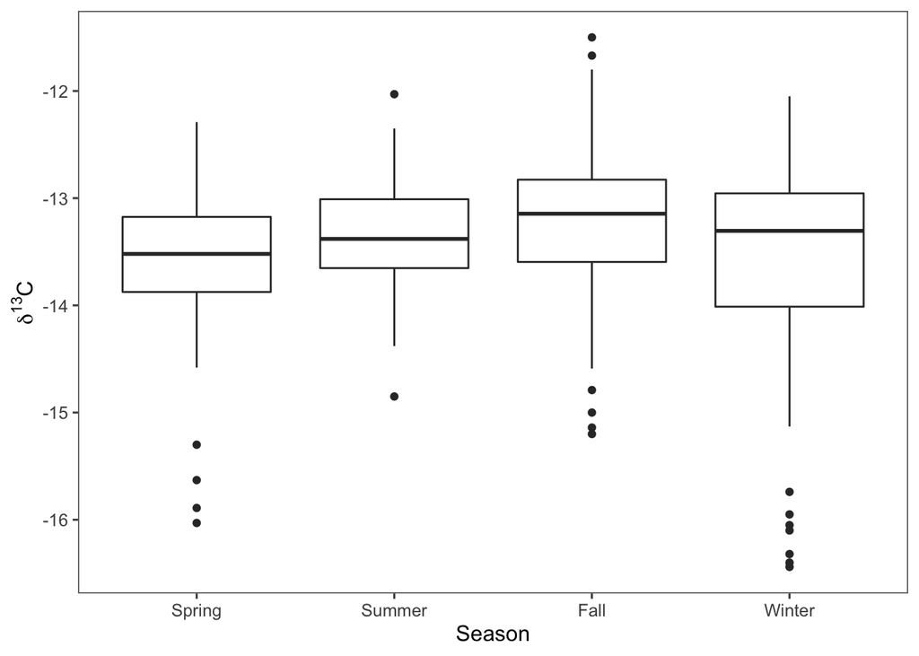

#### Nitrogen

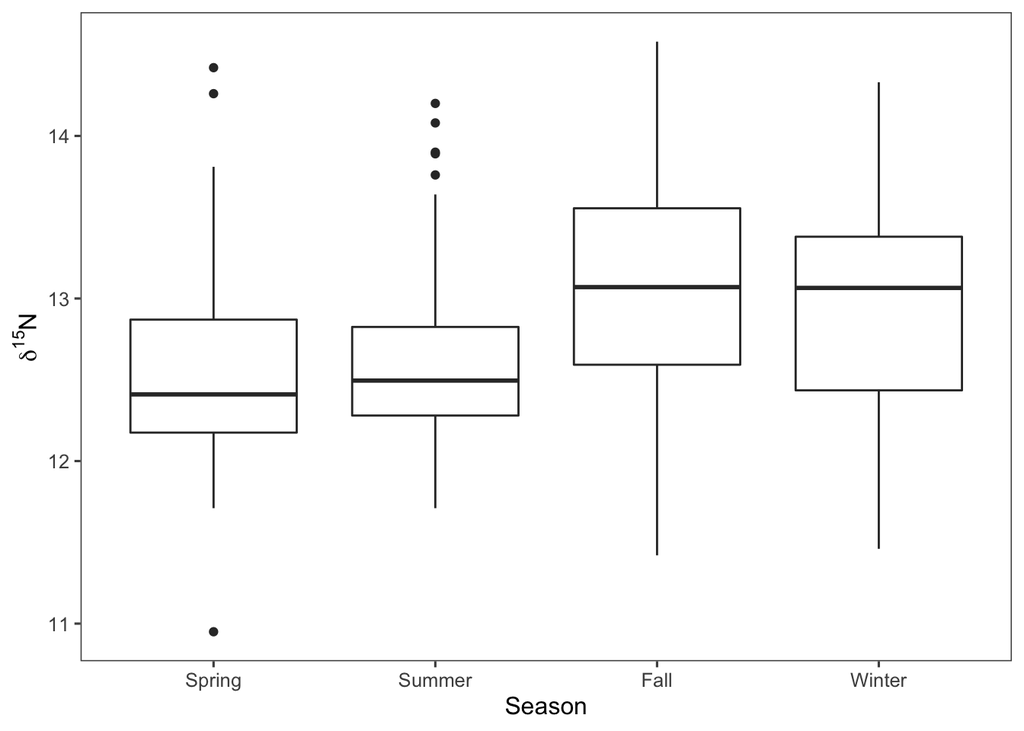

Looks like there is very little variation from season to season, with the biggest mean value shifts at about 0.5‰.

## Stats for Seasons

#### Anova

```r
cseason.aov <- aov(C~Season*OtterID, data = whisker)
summary(cseason.aov)
```

```
##                 Df Sum Sq Mean Sq F value   Pr(>F)
## Season           3   7.36   2.454  15.028 9.43e-09 ***
## OtterID         28  98.19   3.507  21.478  < 2e-16 ***
## Season:OtterID  81  44.81   0.553   3.388 7.62e-12 ***
## Residuals      176  28.74   0.163
## ---
## Signif. codes:  0 '***' 0.001 '**' 0.01 '*' 0.05 '.' 0.1 ' ' 1
```

```r
nseason.aov <- aov(N~Season*OtterID, data = whisker)
summary(nseason.aov)
```

```
##                 Df Sum Sq Mean Sq F value   Pr(>F)
## Season           3  11.62   3.875  27.808 9.07e-15 ***
## OtterID         28  65.99   2.357  16.914  < 2e-16 ***
## Season:OtterID  81  25.00   0.309   2.215 6.41e-06 ***
## Residuals      176  24.52   0.139
## ---
## Signif. codes:  0 '***' 0.001 '**' 0.01 '*' 0.05 '.' 0.1 ' ' 1
```

Season for both C and N are significant. But you can also see that there is an interaction with Otter ID. Which is where my problem starts.

#### Pairwise test for seasons

```r
pairwise.t.test(x=whisker$C, g=whisker$Season, p.adj="none")
```

```
##
##  Pairwise comparisons using t tests with pooled SD
##
## data:  whisker$C and whisker$Season
##
##        Spring Summer Fall
## Summer 0.0708 -      -
## Fall   0.0041 0.2997 -
## Winter 0.9503 0.0740 0.0041
##
## P value adjustment method: none
```

```r
pairwise.t.test(x=whisker$N, g=whisker$Season, p.adj="none")
```

```
##
##  Pairwise comparisons using t tests with pooled SD
##
## data:  whisker$N and whisker$Season
##
##        Spring  Summer  Fall
## Summer 0.50560 -       -
## Fall   7.5e-06 0.00015 -
## Winter 0.00051 0.00554 0.25492
##
## P value adjustment method: none
```

Nitrogen: Spring/Fall, Spring/Winter, Summer/Fall, and Winter/Summer are significant, which is how I originally matched up the seasons.

```r
pairwise.t.test(x=whisker$C, g=whisker$Season, p.adj="bonferroni")
```

```
##
##  Pairwise comparisons using t tests with pooled SD
##
## data:  whisker$C and whisker$Season
##
##        Spring Summer Fall
## Summer 0.425  -      -
## Fall   0.025  1.000  -
## Winter 1.000  0.444  0.024
##
## P value adjustment method: bonferroni
```

```r
pairwise.t.test(x=whisker$N, g=whisker$Season, p.adj="bonferroni")
```

```
##
##  Pairwise comparisons using t tests with pooled SD
##
## data:  whisker$N and whisker$Season
##
##        Spring  Summer  Fall
## Summer 1.00000 -       -
## Fall   4.5e-05 0.00089 -
## Winter 0.00305 0.03324 1.00000
##
## P value adjustment method: bonferroni
```

```r
pairwise.t.test(x=whisker$C, g=whisker$Season, p.adj="holm")
```

```
##
##  Pairwise comparisons using t tests with pooled SD
##
## data:  whisker$C and whisker$Season
##
##        Spring Summer Fall
## Summer 0.283  -      -
## Fall   0.024  0.599  -
## Winter 0.950  0.283  0.024
##
## P value adjustment method: holm
```

```r
pairwise.t.test(x=whisker$N, g=whisker$Season, p.adj="holm")
```

```
##
##  Pairwise comparisons using t tests with pooled SD
##
## data:  whisker$N and whisker$Season
##
##        Spring  Summer  Fall
## Summer 0.50983 -       -
## Fall   4.5e-05 0.00074 -
## Winter 0.00203 0.01662 0.50983
##
## P value adjustment method: holm
```

#### Tukey HSD

```r
TukeyHSD(aov(C~Season, data=whisker))
```

```
##   Tukey multiple comparisons of means
##     95% family-wise confidence level
##
## Fit: aov(formula = C ~ Season, data = whisker)
##
## $Season
##                       diff         lwr         upr     p adj
## Summer-Spring  0.238885667 -0.10149554  0.57926687 0.2689859
## Fall-Spring    0.375258216  0.03974132  0.71077511 0.0214541
## Winter-Spring  0.007950524 -0.32109687  0.33699792 0.9999125
## Fall-Summer    0.136372549 -0.20285031  0.47559541 0.7267207
## Winter-Summer -0.230935143 -0.56376055  0.10189026 0.2787493
## Winter-Fall   -0.367307692 -0.69515671 -0.03945868 0.0211470
```

```r
TukeyHSD(aov(N~Season, data=whisker))
```

```
##   Tukey multiple comparisons of means
##     95% family-wise confidence level
##
## Fit: aov(formula = N ~ Season, data = whisker)
##
## $Season
##                      diff         lwr       upr     p adj
## Summer-Spring  0.07200497 -0.20715990 0.3511698 0.9095921
## Fall-Spring    0.48594288  0.21076749 0.7611183 0.0000441
## Winter-Spring  0.36724630  0.09737689 0.6371157 0.0028444
## Fall-Summer    0.41393791  0.13572306 0.6921528 0.0008529
## Winter-Summer  0.29524133  0.02227337 0.5682093 0.0282038
## Winter-Fall   -0.11869658 -0.38758313 0.1501900 0.6645859
```

Tukey’s gives similar as Bonferroni and Holm. There are significant values here, but really - the main takeaway needs to be that these means are only 0.3-0.5‰. which is VERY SMALL in and ecological sense.

## Normality

I didn’t initially test for normality in either Carbon or Nitrogen values

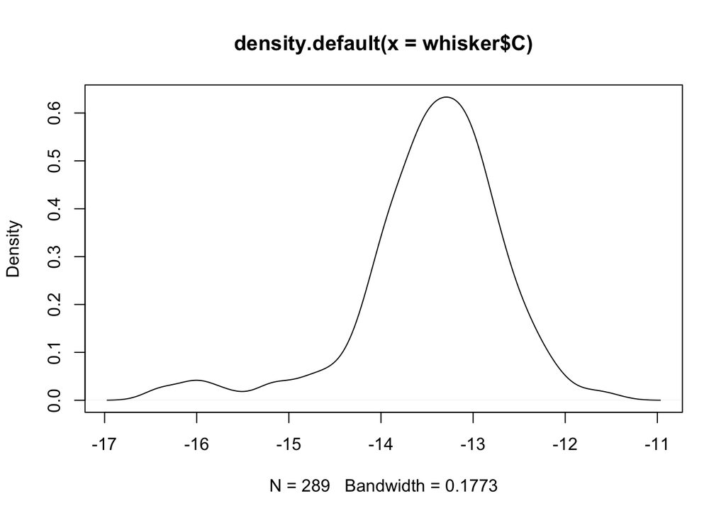

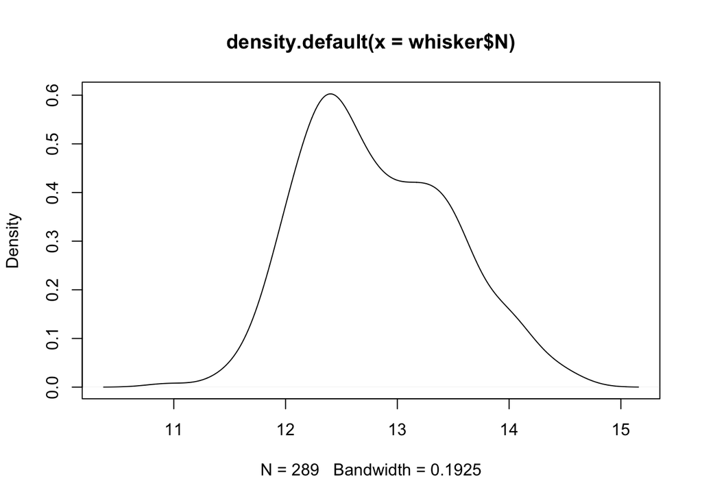

```r
plot(density(whisker$C));plot(density(whisker$N))
```

```r
shapiro.test(whisker$C); shapiro.test(whisker$N)
```

```
##
##  Shapiro-Wilk normality test
##
## data:  whisker$C
## W = 0.91951, p-value = 2.33e-11
```

```
##
##  Shapiro-Wilk normality test
##
## data:  whisker$N
## W = 0.98155, p-value = 0.0008762
```

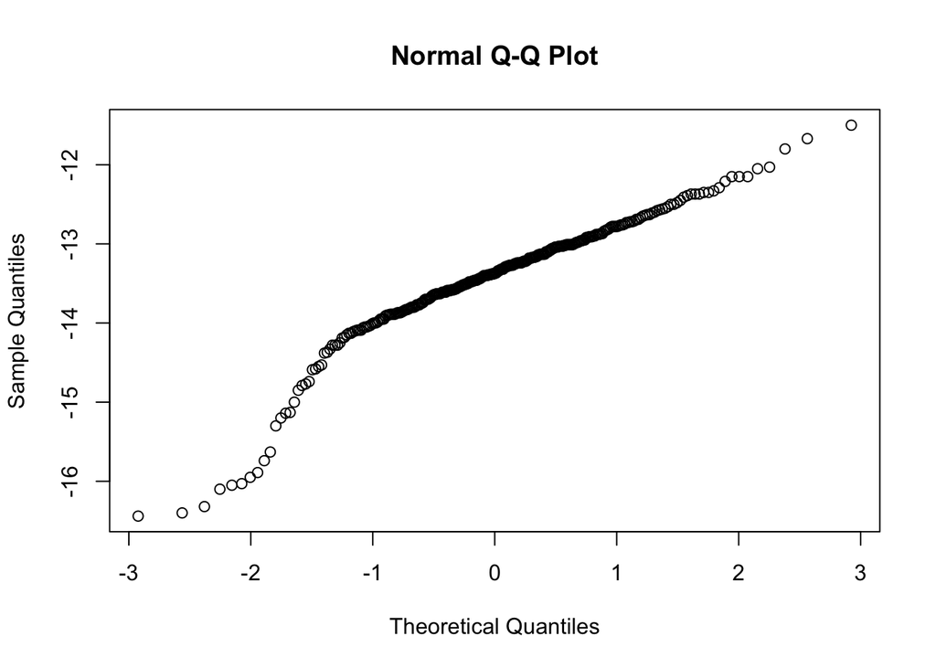

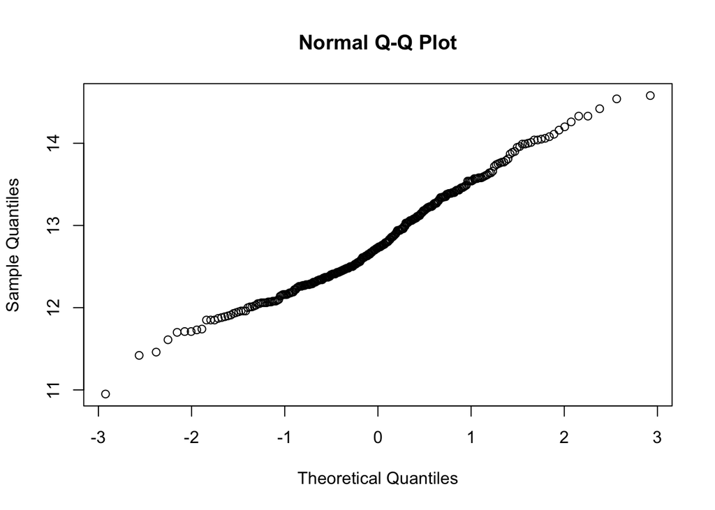

```r
qqnorm(whisker$C); qqnorm(whisker$N)
```